# Homework 4 Template

Kevin Russell

# Problem 1 [30 Points Total]

### Question (i). 7 points.

The ANSUR II MALE Public.csv and ANSUR II FEMALE Public.csv files are available on HuskyCT. Read these files into R, then combine them into a single a data frame containing one row for each individual.

From this data frame, create a new data frame called “measurements” comprised of the following columns in the following order:

- subjectid
- sex
- Age
- forearmcenterofgriplength
- forearmcircumferenceflexed
- forearmhandlength
- handbreadth
- handcircumference
- handlength
- palmlength
- thumbtipreach
- wristcircumference
- anklecircumference
- balloffootcircumference
- balloffootlength
- calfcircumference
- footbreadthhorizontal
- footlength
- heelanklecircumference
- heelbreadth
- kneeheightmidpatella
- kneeheightsitting

```r
library(dplyr)
library(tidyverse)
```

```r
library(ggplot2)
library(jpeg)
library(raster)
library(rvest)
library(tiff)
male <- read.csv("C:/Users/kruss/Downloads/ANSUR II MALE Public(1).csv")
female <- read.csv("C:/Users/kruss/Downloads/ANSUR II FEMALE Public.csv")
```

```r
both <- bind_rows(male, female)
```

```r
measurements <- both |>
  dplyr::select(subjectid, Gender, Age, forearmcenterofgriplength, forearmcircumferenceflexed, forearmhandlength, handbreadth, handcircumference, handlength, palmlength, thumbtipreach, wristcircumference, anklecircumference, balloffootcircumference, balloffootlength, calfcircumference, footbreadthhorizontal, footlength, heelanklecircumference, heelbreadth, kneeheightmidpatella, kneeheightsitting)
```

```r
measurements <- measurements |>
  mutate(sex = Gender)
```

```r
measurements <- measurements |>
  dplyr::select(subjectid, sex, Age, forearmcenterofgriplength, forearmcircumferenceflexed, forearmhandlength, handbreadth, handcircumference, handlength, palmlength, thumbtipreach, wristcircumference, anklecircumference, balloffootcircumference, balloffootlength, calfcircumference, footbreadthhorizontal, footlength, heelanklecircumference, heelbreadth, kneeheightmidpatella, kneeheightsitting)
```

### Question (ii). 8 points.

Make a graphic depicting the percentage of the variance explained by each of the principal components.

```r
library(broom)
```

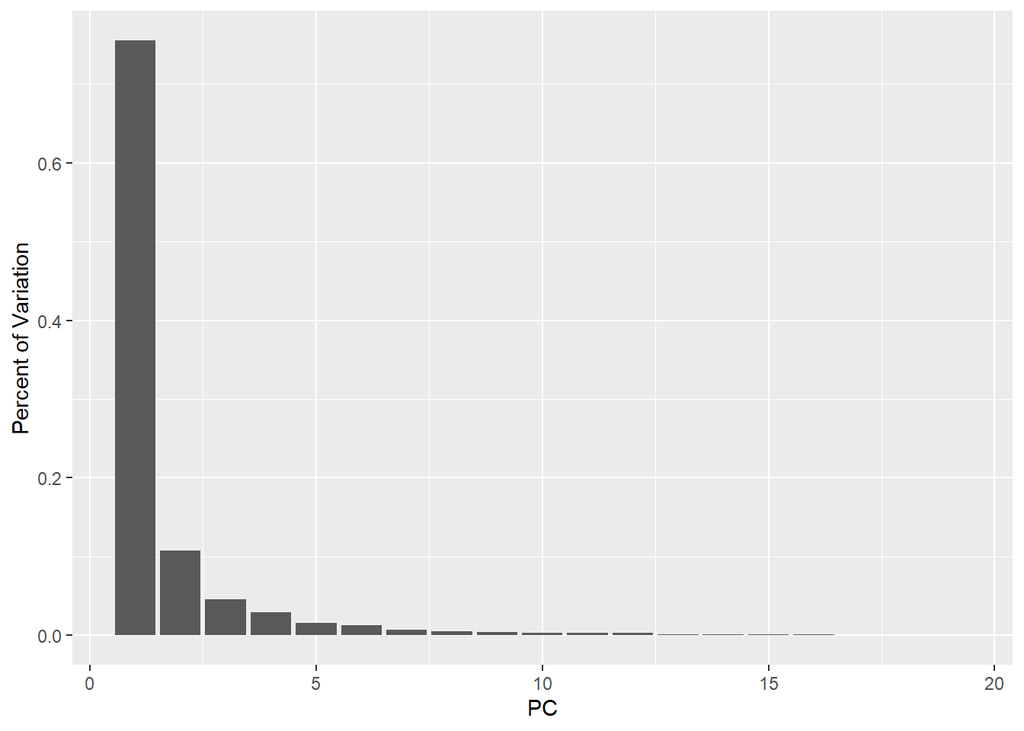

```r
pca <- measurements |>
  dplyr::select(!c(sex, Age, subjectid)) |>
  prcomp()

pca_analysis <- pca |>
  tidy(matrix = "pcs")

pca_analysis |>
  ggplot(aes(x = PC, y = percent)) +
  geom_bar(stat = "identity") +
  labs(y = "Percent of Variation")
```

What percentage of the variance is explained by the first four components together?

```r
#93.898% of the variation.
pca_analysis
```

```
## # A tibble: 19 × 4
##       PC std.dev percent cumulative
##    <dbl>   <dbl>   <dbl>      <dbl>
##  1     1   89.9  0.755        0.755
##  2     2   34.0  0.108        0.863
##  3     3   22.2  0.0461       0.909
##  4     4   17.9  0.0298       0.939
##  5     5   13.0  0.0159       0.955
##  6     6   11.8  0.0129       0.968
##  7     7    8.47 0.00671      0.975
##  8     8    7.47 0.00523      0.980
##  9     9    6.56 0.00402      0.984
## 10    10    6.09 0.00346      0.987
## 11    11    5.91 0.00327      0.991
## 12    12    5.53 0.00286      0.993
## 13    13    4.33 0.00175      0.995
## 14    14    3.82 0.00136      0.996
## 15    15    3.55 0.00118      0.998
## 16    16    3.12 0.00091      0.999
## 17    17    2.73 0.0007       0.999
## 18    18    2.34 0.00051      1.00
## 19    19    1.54 0.00022      1
```